# 1_10

#### Regularization Hyperparameters

- unconstrained decision tree fits the training data closely, and most likely overfitting it, such a model is called nonparametric model
- parametric model has predetermined number of parameters to reduce the risk of overfitting
- regularization hyperparameters
  - max_depth, the maximum depth of the tree
  - min_samples_split, the minimum number of samples required to split an internal node
  - min_samples_leaf, the minimum number of samples required to be at a leaf node
  - min_weight_fraction_leaf, the minimum weighted fraction of the sum total of weights (of all the input samples) required to be at a leaf node
  - max_features, the number of features to consider when looking for the best split
  - max_leaf_nodes, the maximum number of leaf nodes
  - min_impurity_decrease, a node will be split if this split induces a decrease of the impurity greater than or equal to this value
  - min_impurity_split, threshold for early stopping in tree growth

#### Pruning

```python
clf = DecisionTreeClassifier(random_state=0)
path = clf.cost_complexity_pruning_path(X_train, y_train)
ccp_alphas, impurities = path.ccp_alphas, path.impurities # get alpha values and their impurities
```

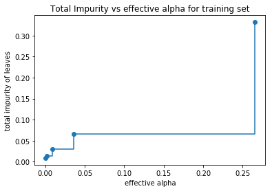

```python
import matplotlib.pyplot as plt
fig, ax = plt.subplots()
ax.plot(ccp_alphas[:-1], impurities[:-1], marker='o', drawstyle="steps-post")
ax.set_xlabel("effective alpha")
ax.set_ylabel("total impurity of leaves")
ax.set_title("Total Impurity vs effective alpha for training set")
```

```python
clfs = []
for ccp_alpha in ccp_alphas:
    clf = DecisionTreeClassifier(random_state=0, ccp_alpha=ccp_alpha)
    clf.fit(X, y)
    clfs.append(clf)
```

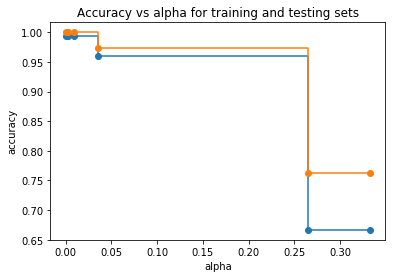

```python
train_scores = [clf.score(X, y) for clf in clfs]
test_scores = [clf.score(X_test, y_test) for clf in clfs]
fig, ax = plt.subplots()
ax.set_xlabel("alpha")
ax.set_ylabel("accuracy")
ax.set_title("Accuracy vs alpha for training and testing sets")
ax.plot(ccp_alphas, train_scores, marker='o', label="train", drawstyle="steps-post")
ax.plot(ccp_alphas, test_scores, marker='o', label="test", drawstyle="steps-post")
```

#### Regression

```python
from sklearn.tree import DecisionTreeRegressor
X = [[0, 0], [2, 2]]
y = [0.5, 2.5]
clf = DecisionTreeRegressor()
clf = clf.fit(X, y)
clf.predict([[1, 1]])
```

```
array([0.5])
```

#### Multi-output

- No correlation between the outputs, build n independent models, independently predict each one of the n outputs
- Output values are themselves correlated, build a single model capable of predicting simultaneously all n outputs

```python
import numpy as np
from sklearn.tree import DecisionTreeRegressor

rng = np.random.RandomState(1)
X = np.sort(200 * rng.rand(100, 1) - 100, axis=0)
y = np.array([np.pi * np.sin(X).ravel(), np.pi * np.cos(X).ravel()]).T
```

```python
y[::5, :] += (0.5 - rng.rand(20, 2)) # add noise
```

```python
regr = DecisionTreeRegressor(max_depth=6)
regr.fit(X, y)

X_test = np.arange(-100.0, 100.0, 0.01)[:, np.newaxis]
y_test = regr.predict(X_test)
```

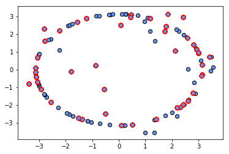

```python
plt.scatter(y[:, 0], y[:, 1], c="cornflowerblue", s=40, edgecolor="black")
plt.scatter(y_test[:, 0], y_test[:, 1], c="cornflowerblue", s=40, edgecolor="red")
```

#### Instability

- Trees love orthogonal decision boundaries, sensitive to rotation
- On way to limit this problem is to use Principal Component Analysis (PCA)

#### Reference

- [Scikit-Learn User Guide](https://scikit-learn.org/stable/modules/tree.html)